# 02_numpy-hw

```python
import numpy as np

import matplotlib.pyplot as plt

%matplotlib inline
```

```python
np.__version__
```

```
'1.18.4'
```

## Структура задания и советы по его решению

Все задания разбиты на 3 уровня сложности:

- **простые** (0.25 балла) – такие пункты обычно требуют вызова одной функции с правильными аргументами;
- **средние** (0.5 баллов) – такие пункты обычно требуют чуть большего осмысления задачи (например, переформулировать ее в терминах `numpy`) и использования нескольких техник/функций для решения;
- **сложные** (1 балл) – такие пункты по своей структуре похожи на задачи среднего уровня сложности, но требуют еще большего расширения сознания (возможно, в ту сторону, в которую не очень и хотелось бы).

Если Вы до этого не были знакомы с библиотекой `numpy`, то рекомендуется делать задания сверху вниз, пропуская сложные. Помните, что в этом задании мы преследуем две цели:

1. научиться пользоваться большинством возможностей библиотеки;
2. набрать баллы за домашку.

Поэтому ни одна из целей не должна быть ущемлена.

Перейдите к первому блоку и сделайте самые простые пункты. Когда почти все такие задачи будут решены, переходите к следующему блоку, решая в нем задачи того же уровня сложности. Как только со всеми простыми задачами будет покончено, переходите к средним задачам.

### Главное правило

На протяжении всего задания **запрещается** использовать циклы и рекурсию.

## Когда дедлайн?

**Жесткий дедлайн:** 10 октября 9:00

## Куда присылать решение?

**Решение состоит из двух файлов: *.ipynb и *.html**.

Чтобы сгенерировать HTML в Jupyter Notebook воспользуйтесь: `File -> Download As -> HTML (.html)`

Решение нужно загрузить на портал. [Инструкция](https://cloud.mail.ru/public/2eT8/4wxP51MoN) по использованию портала. Файлы можно поместить в zip-архив.

## Размерность массивов (1 балл)

Во всех заданиях этого блока **запрещается** руками модифицировать любые атрибуты массива.

```python
a = np.ones(6, dtype=int)
a
```

```
array([1, 1, 1, 1, 1, 1])
```

Превратите массив $a$ в вектор-строку `a.shape == (1, 6)`. Тип получившегося объекта по-прежнему должен быть `np.array`. **(0.25 балла)**

**Запрещается** использовать `reshape`.

```python
a[np.newaxis,:]
# put your code here
```

```
array([[1, 1, 1, 1, 1, 1]])
```

Превратите массив $a$ в вектор-столбец `a.shape == (6, 1)`. Тип получившегося объекта по-прежнему должен быть `np.array`. **(0.25 балла)**

**Запрещается** использовать `reshape`. Воспользуйтесь способом, который вы **НЕ** использовали в предыдущем пункте. Если в документации библиотеки он описан как эквивалентный, то этот способ подойдет.

```python
a[:,np.newaxis]
# put your code here
```

```
array([[1],
       [1],
       [1],
       [1],
       [1],
       [1]])
```

Превратите массив $a$ в массив $2 \times 3$. **(0.25 балла)**

```python
a.reshape(2, 3)# put your code here
```

```
array([[1, 1, 1],
       [1, 1, 1]])
```

```python
np.random.seed(7892)

cols = np.random.randint(low=10, high=20, size=1)
rows = 5

a = np.ones(cols * rows)
a.shape
```

```
(50,)
```

Превратите массив $a$ в массив с 5 строками. **(0.25 балла)**

**Запрещается** использовать информацию о размере массива $a$.

**Разрешается** использовать переменную rows или число 5.

```python
a.reshape(5, -1)
```

```
array([[1., 1., 1., 1., 1., 1., 1., 1., 1., 1.],
       [1., 1., 1., 1., 1., 1., 1., 1., 1., 1.],
       [1., 1., 1., 1., 1., 1., 1., 1., 1., 1.],
       [1., 1., 1., 1., 1., 1., 1., 1., 1., 1.],
       [1., 1., 1., 1., 1., 1., 1., 1., 1., 1.]])
```

## Индексация (3.75 балла)

```python
A = np.arange(36).reshape(-1, 6)
A
```

```
array([[ 0,  1,  2,  3,  4,  5],
       [ 6,  7,  8,  9, 10, 11],
       [12, 13, 14, 15, 16, 17],
       [18, 19, 20, 21, 22, 23],
       [24, 25, 26, 27, 28, 29],
       [30, 31, 32, 33, 34, 35]])
```

Получите следующие срезы. **(по 0.25 балла за каждый срез; итого 1.25 балла за задание)**

В первых 4-х срезах **запрещается** использовать `np.ix_` и его аналоги.

Поместите результат в перменную `A_slice`.

```python
# put your code here
A_slice = A[2:5, 2:5]

A_slice_res = np.array([[14, 15, 16],
                        [20, 21, 22],
                        [26, 27, 28]])

assert (A_slice == A_slice_res).all()
```

```python
# put your code here
A_slice = A[3:, ::2]

A_slice_res = np.array([[18, 20, 22],
                        [24, 26, 28],
                        [30, 32, 34]])

assert (A_slice == A_slice_res).all()
```

```python
# put your code here
A_slice = A[-1:1:-1, -2:1:-1]

A_slice_res = np.array([[34, 33, 32],
                        [28, 27, 26],
                        [22, 21, 20],
                        [16, 15, 14]])

assert (A_slice == A_slice_res).all()
```

```python
# put your code here
A_slice = A[::2, [1, 3, 4]]

A_slice_res = np.array([[ 1,  3,  4],
                        [13, 15, 16],
                        [25, 27, 28]])

assert (A_slice == A_slice_res).all()
```

```python
# put your code here
A_slice = A[[1, 3, 4]][:,[1, 3, 4]]

A_slice_res = np.array([[ 7,  9, 10],
                        [19, 21, 22],
                        [25, 27, 28]])

assert (A_slice == A_slice_res).all()
```

Создайте массив $A$ в виде [шахматной доски](https://ru.wikipedia.org/wiki/%D0%A8%D0%B0%D1%85%D0%BC%D0%B0%D1%82%D0%BD%D0%B0%D1%8F_%D0%B4%D0%BE%D1%81%D0%BA%D0%B0). **(0.25 балла)**

**Подсказка:** задание решается с использованием индексации в несколько действий, не обязательно помещать все в одно выражение.

```python
# Здесь возможно огромное количество вариантов решения

# put your code here
A = np.ones((8, 8), dtype='int64')
A[::2, ::2], A[1::2, 1::2] = 0, 0
A
```

```
array([[0, 1, 0, 1, 0, 1, 0, 1],
       [1, 0, 1, 0, 1, 0, 1, 0],
       [0, 1, 0, 1, 0, 1, 0, 1],
       [1, 0, 1, 0, 1, 0, 1, 0],
       [0, 1, 0, 1, 0, 1, 0, 1],
       [1, 0, 1, 0, 1, 0, 1, 0],
       [0, 1, 0, 1, 0, 1, 0, 1],
       [1, 0, 1, 0, 1, 0, 1, 0]])
```

Возьмите столбцы, в которых есть хотя бы одно значение равно 7. **(0.25 балла)**

```python
np.random.seed(7964)

A = np.random.randint(0, 8, size=(5, 5))
A[2, 3] = 10
A
```

```
array([[ 5,  6,  2,  4,  4],
       [ 1,  2,  3,  5,  0],
       [ 0,  2,  3, 10,  7],
       [ 2,  3,  6,  7,  7],
       [ 7,  3,  6,  2,  2]])
```

```python
A[:,(A==7).any(axis=0)]
# put your code here
```

```
array([[ 5,  4,  4],
       [ 1,  5,  0],
       [ 0, 10,  7],
       [ 2,  7,  7],
       [ 7,  2,  2]])
```

Найдите индексы значений, которые меньше 4. **(0.25 балла)**

```python
np.where(A < 4)
# put your code here
```

```
(array([0, 1, 1, 1, 1, 2, 2, 2, 3, 3, 4, 4, 4]),
 array([2, 0, 1, 2, 4, 0, 1, 2, 0, 1, 1, 3, 4]))
```

Найдите индексы значений, которые меньше 4 и не меньше 2. **(0.25 балла)**

```python
np.where((A >= 2) & (A < 4))
# put your code here
```

```
(array([0, 1, 1, 2, 2, 3, 3, 4, 4, 4]), array([2, 1, 2, 1, 2, 0, 1, 1, 3, 4]))
```

Получите значения по этим индексам. **(0.25 балла)**

```python
# put your code here
A[np.where((A >= 2) & (A < 4))]
```

```
array([2, 2, 3, 2, 3, 2, 3, 3, 2, 2])
```

Найдите все индексы, где достигаются максимумы по строке в массиве $B$. **(0.5 балла)**

**Подсказка:** `np.argmax` тут не подойдет. Почему?

```python
B = [[0, 0, 3, 1, 3, 2],
     [2, 3, 0, 0, 3, 0],
     [0, 1, 2, 0, 0, 2],
     [2, 0, 2, 0, 2, 1],
     [1, 1, 0, 0, 1, 3]]
B = np.asarray(B)
B
```

```
array([[0, 0, 3, 1, 3, 2],
       [2, 3, 0, 0, 3, 0],
       [0, 1, 2, 0, 0, 2],
       [2, 0, 2, 0, 2, 1],
       [1, 1, 0, 0, 1, 3]])
```

```python
# put your code here
# np.apply_along_axis(np.argwhere(B==np.max(B, axis=1)), 1, B)

#np.argwhere(B[0]==np.max(B, axis=1)[0])
```

Рассмотрим массив $A$. Модифицируйте предыдущее решение так, чтобы получился массив $C$ следующего вида **(0.5 балла)**:

- значения в матрице $C$ на позициях, где условие выполнено, совпадает со значениями на позициях в матрице $A$;
- иначе – `-np.inf`.

Сохраните результат в переменную $C$.

```python
A = [[3, 1, 4, 5, 1, 2],
     [3, 3, 2, 4, 2, 2],
     [4, 1, 0, 1, 0, 2],
     [1, 0, 4, 3, 4, 3],
     [4, 2, 0, 1, 3, 4]]
A = np.asarray(A)
A
```

```
array([[3, 1, 4, 5, 1, 2],
       [3, 3, 2, 4, 2, 2],
       [4, 1, 0, 1, 0, 2],
       [1, 0, 4, 3, 4, 3],
       [4, 2, 0, 1, 3, 4]])
```

```python
# put your code here
# C = ...
```

Найдите индексы, где $C$ принимает наибольшие значения. **(0.25 балла)**

**Замечание:** помните о том, что `C.dtype == dtype('float')`, и числа с плавующей точкой нельзя сравнивать через `==`.

```python
# put your code here
```

## Операции над массивами (4.5 балла)

Найдите максимальное значение в каждой строке массива $A$. **(0.25 балла)**

```python
np.random.seed(7964)

A = np.random.randint(0, 8, size=(5, 5))
A[2, 3] = 10
A
```

```
array([[ 5,  6,  2,  4,  4],
       [ 1,  2,  3,  5,  0],
       [ 0,  2,  3, 10,  7],
       [ 2,  3,  6,  7,  7],
       [ 7,  3,  6,  2,  2]])
```

```python
np.amax(A, axis=1)
# put your code here
```

```
array([ 6,  5, 10,  7,  7])
```

Найдите индексы максимального значения массива $A$. **(0.25 балла)**

**Запрещается** считать координаты максимума руками. Найдите для этого специальную функцию.

```python
# put your code here
np.unravel_index(np.argmax(A, axis=None), A.shape)
```

```
(2, 3)
```

Добавьте в массиве $A$ слева колонку, состоящую из 1. Сохраните свой результат в переменную $A$. **(0.25 балла)**

```python
# put your code here
A = np.hstack((np.ones((A.shape[0], 1), dtype=A.dtype), A))
A
```

```
array([[ 1,  5,  6,  2,  4,  4],
       [ 1,  1,  2,  3,  5,  0],
       [ 1,  0,  2,  3, 10,  7],
       [ 1,  2,  3,  6,  7,  7],
       [ 1,  7,  3,  6,  2,  2]])
```

```python
np.random.seed(7942)

W = (np.random.random(size=A.shape) > 0.5).astype(int)
W
```

```
array([[0, 1, 0, 0, 1, 0],
       [1, 0, 1, 1, 1, 1],
       [0, 0, 1, 0, 1, 0],
       [0, 0, 0, 1, 0, 1],
       [1, 0, 0, 1, 1, 1]])
```

Умножьте массив $A$ на массив $W$ поэлементно. **(0.25 балла)**

```python
# put your code here
A*W
```

```
array([[ 0,  5,  0,  0,  4,  0],
       [ 1,  0,  2,  3,  5,  0],
       [ 0,  0,  2,  0, 10,  0],
       [ 0,  0,  0,  6,  0,  7],
       [ 1,  0,  0,  6,  2,  2]])
```

Умножьте массив $A$ на массив $W^T$ матрично. **(0.25 балла)**

```python
# put your code here
A @ W.T
```

```
array([[ 9, 17, 10,  6, 11],
       [ 6, 11,  7,  3,  9],
       [10, 23, 12, 10, 21],
       [ 9, 24, 10, 13, 21],
       [ 9, 14,  5,  8, 11]])
```

```python
np.random.seed(4589)

X = np.random.randint(0, 2, size=(5, 10))
X
```

```
array([[0, 1, 1, 0, 1, 0, 1, 1, 1, 0],
       [1, 0, 0, 1, 0, 0, 1, 0, 1, 0],
       [0, 1, 0, 0, 0, 1, 1, 1, 0, 1],
       [1, 1, 0, 0, 0, 1, 1, 1, 0, 1],
       [0, 0, 0, 1, 1, 1, 0, 1, 1, 0]])
```

```python
x = np.arange(1, 11, 1)
x
```

```
array([ 1,  2,  3,  4,  5,  6,  7,  8,  9, 10])
```

Найдите скалярное произведение вектора $x$ с каждым из 5 векторов массива $X$. **(0.25 балла)**

```python
X @ x
```

```
array([34, 21, 33, 34, 32])
```

Отнормируйте столбцы массива $X$ по $l1$-норме. **(0.25 балла)**

```python
X/np.linalg.norm(X, ord=1, axis=0)
```

```
array([[0.        , 0.33333333, 1.        , 0.        , 0.5       ,
        0.        , 0.25      , 0.25      , 0.33333333, 0.        ],
       [0.5       , 0.        , 0.        , 0.5       , 0.        ,
        0.        , 0.25      , 0.        , 0.33333333, 0.        ],
       [0.        , 0.33333333, 0.        , 0.        , 0.        ,
        0.33333333, 0.25      , 0.25      , 0.        , 0.5       ],
       [0.5       , 0.33333333, 0.        , 0.        , 0.        ,
        0.33333333, 0.25      , 0.25      , 0.        , 0.5       ],
       [0.        , 0.        , 0.        , 0.5       , 0.5       ,
        0.33333333, 0.        , 0.25      , 0.33333333, 0.        ]])
```

Таблица умножения. Создайте массив $9 \times 9$, элементы которого являются произведениями индексов столбца и строки. **(0.5 балла)**

```python
# put your code here
IxI = (np.indices((9, 9)) + 1).prod(axis=0)
IxI
```

```
array([[ 1,  2,  3,  4,  5,  6,  7,  8,  9],
       [ 2,  4,  6,  8, 10, 12, 14, 16, 18],
       [ 3,  6,  9, 12, 15, 18, 21, 24, 27],
       [ 4,  8, 12, 16, 20, 24, 28, 32, 36],
       [ 5, 10, 15, 20, 25, 30, 35, 40, 45],
       [ 6, 12, 18, 24, 30, 36, 42, 48, 54],
       [ 7, 14, 21, 28, 35, 42, 49, 56, 63],
       [ 8, 16, 24, 32, 40, 48, 56, 64, 72],
       [ 9, 18, 27, 36, 45, 54, 63, 72, 81]])
```

```python
N, M = 5, 4
```

Создайте массив с повторами. Разрешается использовать константы N и M. **(0.25 балла)**

**Запрещается** использовать циклы.

```python
np.repeat(np.arange(N), M)
# put your code here
```

```
array([0, 0, 0, 0, 1, 1, 1, 1, 2, 2, 2, 2, 3, 3, 3, 3, 4, 4, 4, 4])
```

Создайте массив с повторами. Разрешается использовать константы N и M. **(0.25 балла)**

**Запрещается** использовать циклы.

```python
# put your code here
np.tile(np.arange(N), M)
```

```
array([0, 1, 2, 3, 4, 0, 1, 2, 3, 4, 0, 1, 2, 3, 4, 0, 1, 2, 3, 4])
```

Даны два небольших массива $A$ размера $M \times N$ и $B$ размера $K \times N$.

Напишите функцию `find_equal_lines(A, B)`, которая найдет все индексы строк массива $A$, содержащиеся в $B$.

**Запрещается** использовать циклы. **(1 балл)**

**Подсказка**: попробуйте поэкспериментировать с размерностью массивов $A$ и $B$.

```python
def find_equal_lines(A, B):
    # put your code here instead of pass
    _, indices, _ = np.intersect1d(A, B, return_indices=True)
    del_elems = np.arange()
    return indices
```

```python
A = np.array([
    [1, 2, 3],
    [1, 2, 1],
    [4, 5, 6],
    [1, 2, 1],
])

B = np.array([
    [4, 5, 6],
    [4, 5, 6],
    [1, 2, 3],
])

#indices = find_equal_lines(A, B)

#assert (indices == [0, 2]).all()
find_equal_lines(A, B)
```

[output not shown]

#### Небольшой набор задачек про изображение

```python
# Если у вас не получается скачать изображение с помощью этого кода, можете скачать его в ручную.
# Сохраните картинку рядом с этим ноутбуком и назовите image.jpg

import urllib.request

urllib.request.urlretrieve(
    'https://upload.wikimedia.org/wikipedia/commons/thumb/3/33/Prokudin-Gorskii-19.jpg/555px-Prokudin-Gorskii-19.jpg',
    'image.jpg'
)
```

```
('image.jpg', <http.client.HTTPMessage at 0x7fc993e81320>)
```

```python
# Install package if it doesn't exist
# !pip install imageio
```

```python
import imageio

def plot_image(img, zoom=1.5):
    assert 2 <= len(img.shape) <= 3

    n_len = 6.5

    n, m = img.shape[:2]
    frac = n / float(m)
    n, m = zoom * frac * n_len, zoom * n_len

    fig = plt.figure(figsize=(n, m))
    ax = fig.add_subplot(111)
    ax.imshow(img)
    ax.axis('off')
    plt.show()
```

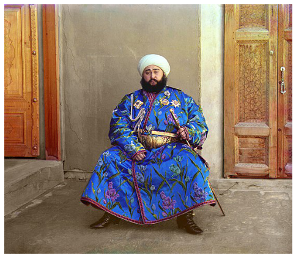

```python
img = imageio.imread('image.jpg')
plot_image(img, zoom=1.5)
```

Найдите среднее значению по каждому из каналов RGB. **(0.25 балла)**

```python
# put your code here
np.array(list(map(np.mean, [img[:,:,0], img[:,:,1], img[:,:,2]])))
```

```
array([139.68829204, 119.95454955, 104.70236862])
```

Посчитайте разброс (среднеквадратичное отклонение) значений по каждому из каналов. **(0.25 балла)**

```python
# put your code here
np.array(list(map(np.std, [img[:,:,0], img[:,:,1], img[:,:,2]])))
```

```
array([54.88760236, 49.51637085, 53.98533328])
```

Поменяйте каналы в обратном порядке. Сохраните результат в переменную img. **(0.25 балла)**

```python
# put your code here
img[:,:,0], img[:,:,-1] = img[:,:,-1].copy(), img[:,:,0].copy()
```

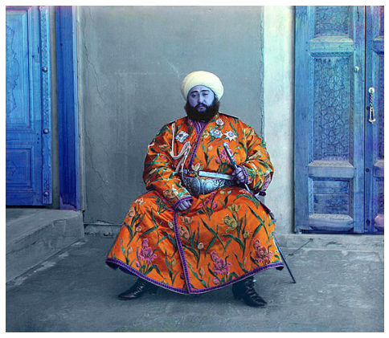

```python
plot_image(img, zoom=1.5)
```

## Случайный классификатор (1.75 балла)

**Случайный классификатор**

```python
from sklearn.base import ClassifierMixin

class RandomClassifier(ClassifierMixin):
    def __init__(self, n_classes=2, seed=8888):
        self.n_classes = n_classes
        self.seed = seed

    def fit(self, X, y=None):
        return self

    def predict_proba(self, X, y=None):
        """
        Method returns np.ndarray y:
            y.shape == (X.shape[0], n_classes)

        y satisfies:
            sum y[i, j] where j in {0..n_classes-1} = 1
        """

        np.random.seed(self.seed)

        X = np.asarray(X)
        y = np.random.rand(X.shape[0], self.n_classes)
        y /= np.expand_dims(y.sum(axis=1), axis=1)

        return y

    def predict(self, X, y=None):
        # already implemented i think

        y_pred = self.predict_proba(X)
        return y_pred.argmax(axis=1)
```

```python
cls = RandomClassifier(n_classes=3, seed=3492)

X = list(range(100))
y_pred = cls.predict_proba(X)

y_pred.shape
```

```
(100, 3)
```

Убедитесь, что классификатор реализован правильно, т.е. сумма вероятностей для каждого примера из выборки равна 1.0. **(0.25 балла)**

Для сравнения с 1.0 используйте функцию `np.isclose` или `np.allclose`. Ваша проверка должна иметь вид:

```
assert condition
```

```python
# put your code here
assert (np.allclose(np.sum(y_pred, axis=1), 1))
```

Для каждого примера из выборки найдите класс-победитель, реализуйте эту логику в методе `predict`. **(0.25 балла)**

```python
y_true = np.array([2, 0, 1, 1, 2, 0, 2, 1, 0, 1, 2, 1, 1, 1, 2, 2, 1, 2, 1, 0, 0, 1,
                   2, 0, 0, 1, 0, 2, 2, 2, 0, 2, 1, 0, 0, 1, 1, 2, 2, 1, 2, 2, 1, 2,
                   0, 2, 2, 0, 1, 1, 0, 1, 2, 1, 1, 2, 0, 1, 1, 2, 0, 2, 2, 0, 0, 0,
                   1, 0, 2, 1, 1, 2, 0, 0, 0, 2, 1, 0, 2, 0, 0, 2, 0, 0, 1, 2, 1, 0,
                   0, 0, 2, 1, 1, 1, 0, 0, 2, 1, 1, 1])

y_pred = cls.predict(X)

assert (y_pred == y_true).all()
```

Найдите количество примеров в каждом классе. **(0.25 балла)**

```python
np.unique(y_pred, return_counts=True)
```

```
(array([0, 1, 2]), array([33, 35, 32]))
```

Напишите метрику LogLoss: **(0.25 балла)**

$$ LogLoss(y, p) = - y log(p) - (1 - y) log(1 - p) $$

- $y$ – истинная метка класса (0 или 1);
- $p$ – предсказанная вероятность того, что объект пренадлежит классу 1.

$$ LogLoss = \frac{1}{N} \sum\limits_{i=1}^N LogLoss(y_i, p_i) $$

```python
def logloss(y_true, y_pred):
    """
    Функция возвращает усредненный лог-лосс для всех точек, см. последнюю формулу.
    """
    return np.mean(-y_true*np.log(y_pred)-(1-y_true)*np.log(1-y_pred))
```

```python
from sklearn.metrics import log_loss

cls = RandomClassifier(n_classes=2, seed=5498)

X = list(range(100))
y_pred = cls.predict_proba(X)[:,1]
y_true = (np.random.random(len(X)) > 0.5).astype(int)

score = logloss(y_true, y_pred)
assert np.allclose(score, log_loss(y_true, y_pred))
```

**Случайный регрессор**

```python
from sklearn.base import RegressorMixin

class RandomRegressor(RegressorMixin):
    def __init__(self, seed=8888):
        self.seed = seed

    def fit(self, X, y=None):
        return self

    def predict(self, X, y=None):
        """
        Method returns np.ndarray y:
            y.shape == (X.shape[0], )
        """

        np.random.seed(self.seed)

        X = np.asarray(X)
        y = np.random.rand(X.shape[0])
        y = 2 * (y - 0.5)

        return y
```

Напишите метрику MSE: **(0.25 балла)**

$$ MSE = \frac{1}{N} \sum\limits_{i=1}^{N} (y_i - \hat y_i) ^ 2 $$

- $y_i$ – истиное значение для i-го примера;
- $\hat y_i$ – предсказанное значение для i-го примера.

```python
def mse(y_true, y_pred):
    return np.mean((y_true-y_pred)*(y_true-y_pred))
```

```python
from sklearn.metrics import mean_squared_error

reg = RandomRegressor(seed=5498)

X = list(range(100))
y_pred = reg.predict(X)
y_true = 2 * ((np.random.random(len(X)) > 0.5).astype(int) - 0.5)

score = mean_squared_error(y_true, y_pred)
assert np.allclose(score, mse(y_true, y_pred))

score
```

```
1.3044196445037217
```

**Голосование**

Предположим, что мы используем набор из `K` различных классификаторов. Результаты работы классификаторов для `N` объектов хранятся в массиве `y_pred`, `y_pred.shape = (N, K)`.

Требуется провести обычное голосование для каждого из объектов и выбрать метку-победитель (метка, встретившаяся для данного объекта наибольшее число раз). Если меток-победителей несколько, допустимо выбрать любую. **(0.5 балла)**

```python
np.random.seed(9866)

y_pred = np.random.randint(0, 3, size=(10, 5))
y_pred
```

```
array([[2, 0, 2, 0, 2],
       [1, 2, 0, 0, 0],
       [2, 0, 1, 1, 2],
       [0, 1, 1, 0, 0],
       [2, 2, 1, 2, 0],
       [1, 2, 2, 1, 0],
       [0, 0, 2, 1, 0],
       [2, 0, 0, 2, 1],
       [1, 1, 0, 1, 1],
       [1, 1, 1, 2, 0]])
```

```python
vote_result = np.apply_along_axis(lambda x: np.bincount(x, minlength=3), 1, y_pred).argmax(axis=1)
winner = np.bincount(vote_result).argmax()
winner
```

```
0
```

## Снежинка Коха (1 балл)

В этом задании предлагается поэтапно научиться строить фрактал [Снежинку Коха](https://en.wikipedia.org/wiki/Koch_snowflake).

[figure not shown]

### Небольшое напоминание про компле́ксные числа.

Комплексным числом $z$ называется упорядоченная пара действительных чисел $(x, y); x, y \in \mathbb{R}$. Число $x$ называется действительной частью $z$, а число $y$ – мнимой частью числа $z$. Для них приняты следующие обозначения: $x = \text{Re}(z)$; $y = \text{Im}(z)$.

Множество комплексных чисел обозначается $\mathbb{C}$ (комплексная плоскость). Комплексное число $z$ можно интерпретировать как точку $(x, y)$ на комплексной плоскости.

Мнимой единицей называется комплексное число $i = (0, 1)$. Таким образом, число $z$ можно записать, как $$z = x + i y$$

Сопряженным к комплексному числу $z$ называется комплексное число $$\hat z = x - i y$$

Модулем комплексного числа $z$ называется $$|z| = \sqrt{x ^ 2 + y ^ 2}$$

Угол $\varphi$, составленный между точкой $z \ne 0$ и положительным направленим полуоси $Ox$, называется аргументом числа $z$. Аргумент числа $z$ определен с точностью до $2 \pi n$: $$ \text{Arg} z = \{ \varphi + 2 \pi n; n \in Z \} $$

Число $\varphi_0 = \varphi \in (-\pi; \pi]$ – называется главным аргументом числа $z$.

Если $\varphi \in \text{Arg} z$, то имеет место представление: $$ z = |z| (\cos \varphi + i \sin \varphi) $$

Используя формулу Эйлера $e^{i \varphi} = \cos \varphi + i \sin \varphi$ имеем $$z = |z| e ^ {i \varphi}$$

Пусть $$ z_1 = x_1 + i y_1 = |z_1| e ^ {i \varphi_1} $$ $$ z_2 = x_2 + i y_2 = |z_2| e ^ {i \varphi_2} $$

Несколько важных свойств комплексных чисел:

- $z_1 \pm z_2 = (x_1 \pm x_2) + i (y_1 \pm y_2)$;
- $z_1 \cdot z_2 = (x_1 x_2 - y_1 y_2) + i (x_1 y_2 + x_2 y_1) = |z_1| |z_2| e ^ {i (\varphi_1 + \varphi_2)} $;
- $z_1 / z_2 = |z_1| / |z_2| e ^ {i (\varphi_1 - \varphi_2)} $;
- $z^n = |z|^n e ^ {i n \varphi} = |z| ^ n (\cos {n \varphi} + i \sin {n \varphi}), n \in \mathbb{Z}$ – формула Муавра-Лапласса.

Корнем $n$-й степени ($n \in \mathbb{N}$) из комплексного числа $z$ называется комплексное число $z_k^n$: $(z_k)^n = z$. В случае $z \ne 0$ имеем $n$ различных корней:

$$ z_k^n = |z|^{1/n} e ^ {i (\varphi + 2 \pi k) / n}; k \in \overline {0, n-1} $$

**Шаг 1:** Напишите функцию, которая извлекает корень из 1. **(0.25 балла)**

```python
def complex_roots(n):
    # put your code here instead of pass
    return 1*np.exp(1j*(2*np.pi*np.arange(n)/n))

roots = complex_roots(5)
roots
```

```
array([ 1.        +0.j        ,  0.30901699+0.95105652j,
       -0.80901699+0.58778525j, -0.80901699-0.58778525j,
        0.30901699-0.95105652j])
```

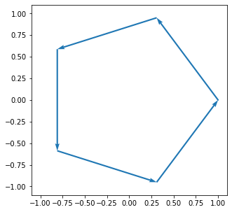

```python
roots = np.append(roots, roots[0])

plt.figure(figsize=(5, 5))
plt.xlim(-1.1, 1.1)
plt.ylim(-1.1, 1.1)

plt.quiver(
    roots.real[:-1],
    roots.imag[:-1],
    roots.real[1:] - roots.real[:-1],
    roots.imag[1:] - roots.imag[:-1],
    scale_units='xy',
    angles='xy',
    scale=1,
    color='C0',
)

plt.show()
```

**Шаг 2:** Напишите функцию, которая строит кривую Коха 1-го порядка. **(0.25 балла)**

Разрешается захаркодить конкретные значения, но эти значения должны выражаться в виде правильной непериодической дроби.

```python
def koch_curve():
    # put your code here instead of pass
    return np.array([
        1 + 0j, 2/3 + 0j,
        0.5 + np.sqrt(3)*1j/6, 1/3 + 0j,
        0 + 0j
    ])

curve = koch_curve()
curve
```

```
array([1.        +0.j        , 0.66666667+0.j        ,
       0.5       +0.28867513j, 0.33333333+0.j        ,
       0.        +0.j        ])
```

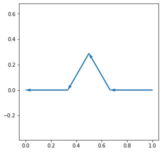

```python
plt.figure(figsize=(5, 5))
plt.axis('equal')

plt.plot(curve.real, curve.imag)

plt.quiver(
    curve.real[:-1],
    curve.imag[:-1],
    curve.real[1:] - curve.real[:-1],
    curve.imag[1:] - curve.imag[:-1],
    scale_units='xy',
    angles='xy',
    scale=1,
    color='C0',
)

plt.show()
```

**Шаг 3:** Заменим стороны в пятиугольнике выше на кривые Коха первого порядка. **(0.5 балла)**

**Замечание:** Чтобы всё точно получилось, проверьте, что обход кривых на шагах 1 и 2 совпадает (либо в обоих сучаях по часовой, либо против).

```python
# add new func
def koch_curve_pro(left, right):
    return np.array([
        right, 2/3/(right-left),
        (right-left)*(0.5 + np.sqrt(3)*1j/6), 1/3/(right-left),
        left
    ])

def change_edges_to_koch_curves(vertices):
    # put your code here instead of pass
    # use koch_curve function here

     # dont know, how do it in another way
     #for i in range((vertices.size-1)*3,-1,3):
     #   vertices = np.hstack((vertices[:i+1], koch_curve_pro(vertices[i], vertices[i+1]), vertices[i+1:]))
     #return np.hstack((vertices, koch_curve_pro(vertices[-1], vertices[0])))
     # and it actualy dont work ...

vertices = complex_roots(5)
line = change_edges_to_koch_curves(vertices)
line.shape
```

[output not shown]

[output not shown]

[figure not shown]

```python
line = np.concatenate([line, [line[0]]])

plt.figure(figsize=(5, 5))
plt.axis('equal')
plt.plot(line.real, line.imag)
plt.show()
```

**Шаг 4:** Построим снежинку Коха.

[figure not shown]

```python
def koch_snowflake(order, scale=10):
    def _koch_snowflake_complex(order):
        if order == 0:
            vertices = complex_roots(3) * 1j
        else:
            vertices = _koch_snowflake_complex(order - 1)
            vertices = change_edges_to_koch_curves(vertices)
        return vertices

    points = scale * _koch_snowflake_complex(order)
    x, y = points.real, points.imag
    return x, y

x, y = koch_snowflake(order=5)

plt.figure(figsize=(8, 8))
plt.axis('equal')
plt.fill(x, y)
plt.show()
```

## Ранжирование и сортировка (1.25 балла)

```python
np.random.seed(9872)

ranks_raw = [np.random.choice(50_000, size=(1_000, ), replace=False) for _ in range(3_000)]
ranks_raw = np.asarray(ranks_raw)
ranks_raw
```

```
array([[ 6640,  7123, 40323, ...,  5829, 36057, 14395],
       [26000,  5194, 35883, ..., 10858, 12871, 41789],
       [35652, 48480, 47942, ..., 33720, 44804, 40471],
       ...,
       [ 2809,  2826, 22387, ..., 49635, 37446,  6057],
       [46735,  5032, 41078, ..., 46014, 16104, 34721],
       [25127, 37952, 30713, ..., 35640, 37865, 22376]])
```

Массив имеет размерность `ranks_raw.shape = (n_domains, n_sources)`.

```python
%%time

def get_best_ranks_slow(ranks, top=10, return_ranks=False):
    indices = ranks.argsort(axis=1)[:,:-top-1:-1]
    result = (indices, )

    if return_ranks:
        ranks = np.sort(ranks, axis=1)[:,:-top-1:-1]
        result += (ranks, )

    return result if len(result) > 1 else result[0]

indices_result = get_best_ranks_slow(ranks_raw, top=15)
```

```
CPU times: user 138 ms, sys: 0 ns, total: 138 ms
Wall time: 137 ms
```

**Шаг 1: (0.25 балла)**

Напишите функцию `get_best_ranks(ranks, top=10)`, которая для каждого строчки выводит `top` индексов столбцов, в которых значение `ranks` максимально.

Результат вашей функции должен быть равен результату работы `get_best_ranks_slow` быть может только за исключением порядка самих индексов в строках.

**Замечание по реализации:** реализация приведенная выше неэффективна, сортировка работает за `O(N log(N))`. Приведите решение, которое работает за `O(N)`, где `N` – размер исходного массива.

**Подсказка:** google "get indexes of n maximum values"

```python
%%time

def get_best_ranks(ranks, top=10):
    # put your code here instead of pass
    return np.argpartition(ranks, -top, axis=1)[:,-top:]

indices = get_best_ranks(ranks_raw, top=15)
indices.shape
```

```
CPU times: user 35.3 ms, sys: 0 ns, total: 35.3 ms
Wall time: 33.9 ms
```

```
(3000, 15)
```

```python
assert (np.sort(indices, axis=1) == np.sort(indices_result, axis=1)).all()
```

**Шаг 2: (0.5 балла)**

Модифицируйте ваше решение, добавив в функцию сортировку так, чтобы результат работы функции `get_best_ranks` **в точности совпадал** с результатом работы функции `get_best_ranks_slow`. Приведите решение, которое работает за `O(N) + O(K log(K))`, где `N` – размер исходного массива, а `K` – число элементов в топе.

**Замечание:** легко убедиться в том, что такое решение не улучшает асимптотику в смысле O-большого. Положим $K = a N; a \in (0, 1]$, тогда

$$ O(K \log K) = O(a \cdot N \cdot \log(a \cdot N)) = \ O(a N \cdot (\log a + \log N) = \ O(a \cdot \log a \cdot N + a \cdot N \cdot \log N) = \ O(N \log N) $$

Однако она зависит от константы $a$, поэтому такой вариант реализации работает быстрее, чем реализация `get_best_ranks_slow`.

```python
%%time

def get_best_ranks(ranks, top=10):
    # put your code here instead of pass
    top_ind = np.argpartition(ranks, -top, axis=1)[:,-top:]
    return np.take_along_axis(ranks, top_ind, axis=1).argsort(axis=1)
    # same elems, but dont same indices

indices = get_best_ranks(ranks_raw, top=15)
indices.shape
```

```
CPU times: user 33.7 ms, sys: 0 ns, total: 33.7 ms
Wall time: 32.5 ms
```

```
(3000, 15)
```

```python
# assert (indices == indices_result).all()
# print(indices, " vs ", indices_result)
```

**Шаг 3: (0.25 балла)**

Поддержите в функции `get_best_ranks` аргумент `return_ranks=True`. В этом случае функция должна возвращать еще и значения ранков, см. реализацию `get_best_ranks_slow`.

**Замечание:** поддержка аргумента не должна приводить к увеличению сложности, т.е. реализация в функции `get_best_ranks_slow` неверная.

```python
_, ranks_result = get_best_ranks_slow(ranks_raw, top=15, return_ranks=True)
```

```python
%%time

def get_best_ranks(ranks, top=10, return_ranks=False):
    # put your code here instead of pass
    pass

_, ranks = get_best_ranks(ranks_raw, top=15, return_ranks=True)
```

[output not shown]

```python
assert np.isclose(ranks, ranks_result).all()
```